# Data Preprocessing

J. Lecumberri, B. Fité & OBustos

2024-04-09

# 1 Libraries loading

```r
library(ggplot2)
library(stringr)
library(readxl)
library(data.table)
library(openxlsx)
library(knitr)
library(kableExtra)
library(RColorBrewer)
library(scales)
library(dplyr)
library(gridExtra)
library(plotly)
library(car)
```

# 2 Data retrieval

Data of the project will be stored in variable `data`.

```r
cd = getwd()
parent_dir <- dirname(cd)
file_path_data = file.path(parent_dir, "data")

data = read.table(file.path(file_path_data, "heart_data.csv"), header = T, sep = ",")
```

## 2.1 Initial data exploration

Our `data` is initially comprised of 70000 observations and 14 variables

```r
dim(data)
```

```
## [1] 70000    14
```

```r
cat("Variable names: \n", colnames(data))
```

```
## Variable names:
##  index id age gender height weight ap_hi ap_lo cholesterol gluc smoke alco active cardio
```

# 3 Data processing

Before any analysis it is important to perform the necessary modifications, additions and filtering steps in order to correct units, missing values, add informative data or remove outliers.

## 3.1 Initial variable modifications and additions

First of all we will correct `age` variable and put it in years units:

```r
data$age = round(data$age / 365, 2)
```

Addition of BMI variable, computed as follows:

$$BMI =
\frac{weight_{kg}}{height_{m}^2}$$

```r
data$BMI = round(data$weight / (data$height / 100)**2, 2)
```

Removal of `id` and `index` variables as row id already covers for this information:

```r
data = data[,c(-1,-2)]
```

## 3.2 Filtering: removal of outliers

By inspecting how the different variables are:

### 3.2.1 Height - Weight

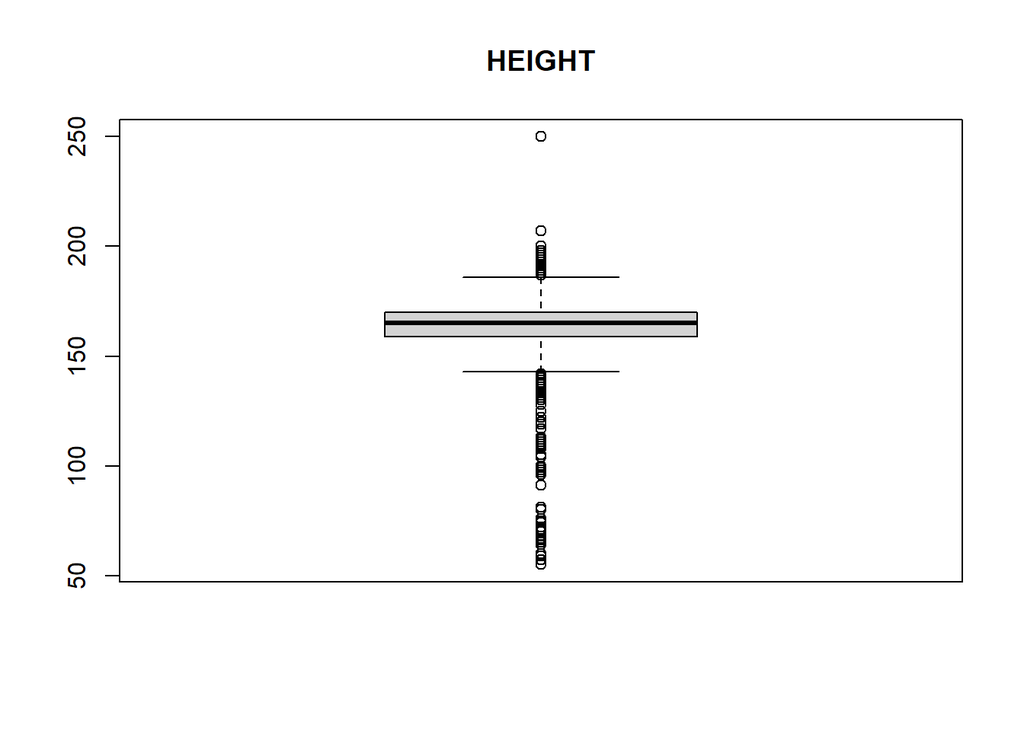

```r
boxplot(data$height, main = "HEIGHT")
```

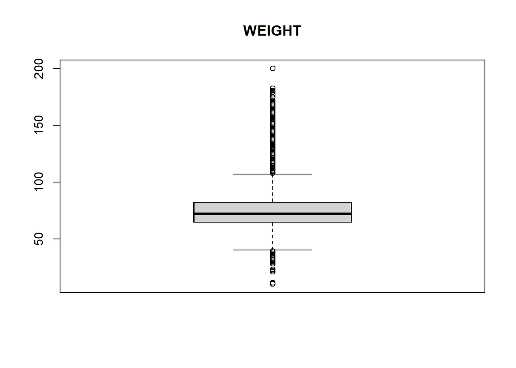

```r
boxplot(data$weight, main = "WEIGHT")
```

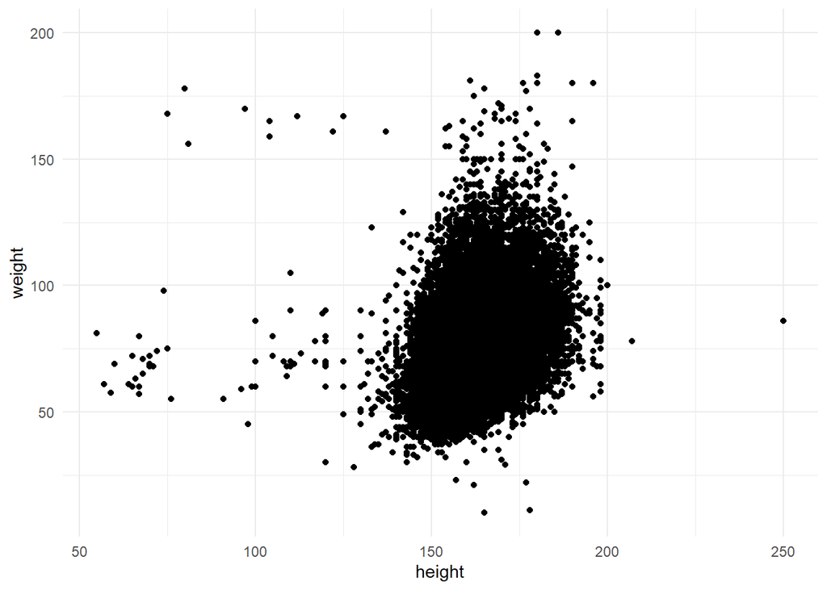

```r
ggplot(data, aes(x = height, y = weight)) +
  geom_point() +
  labs(x = "height", y = "weight") +
  theme_minimal()
```

We can see how in `height` and `weight` have a lot of clears outliers and clear data errors:

```r
cat("Maximum value of height", max(data$height),"\n")
```

```
## Maximum value of height 250
```

```r
cat("Maximum value of weight", max(data$weight),"\n")
```

```
## Maximum value of weight 200
```

```r
cat("Minumum value of height", min(data$height),"\n")
```

```
## Minumum value of height 55
```

```r
cat("Minumum value of weight", min(data$weight),"\n")
```

```
## Minumum value of weight 10
```

Filtering applied:

```r
data <- data[data$height >= 130 & data$height <= 230, ]
data <- data[data$weight >= 45,]
```

Once filtered is looks as follows:

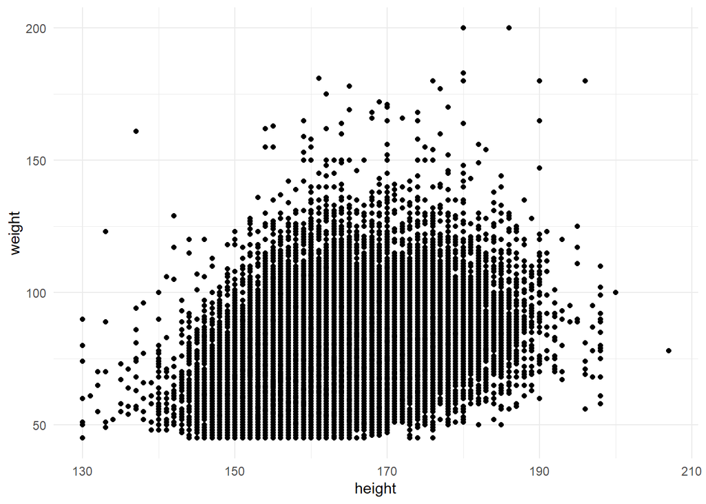

```r
ggplot(data, aes(x = height, y = weight)) +
  geom_point() +
  labs(x = "height", y = "weight") +
  theme_minimal()
```

### 3.2.2 Systolic and diastolic pressures

First of all let’s check how these two variables are distributed:

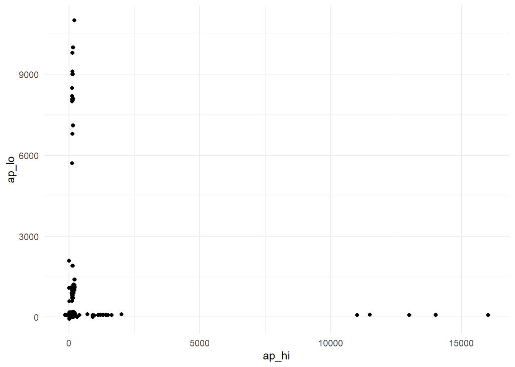

```r
ggplot(data, aes(x = ap_hi, y = ap_lo)) +
  geom_point() +
  labs(x = "ap_hi", y = "ap_lo") +
  theme_minimal()
```

We can observe clear outliers:

```r
cat("Maximum value of systolic P", max(data$ap_hi),"\n")
```

```
## Maximum value of systolic P 16020
```

```r
cat("Maximum value of diastolic P", max(data$ap_lo),"\n")
```

```
## Maximum value of diastolic P 11000
```

```r
cat("Minumum value of systolic P", min(data$ap_hi),"\n")
```

```
## Minumum value of systolic P -150
```

```r
cat("Minumum value of diastolic P", min(data$ap_lo),"\n")
```

```
## Minumum value of diastolic P -70
```

So we will filter data by sources found for normal values of systolic and diastolic pressure

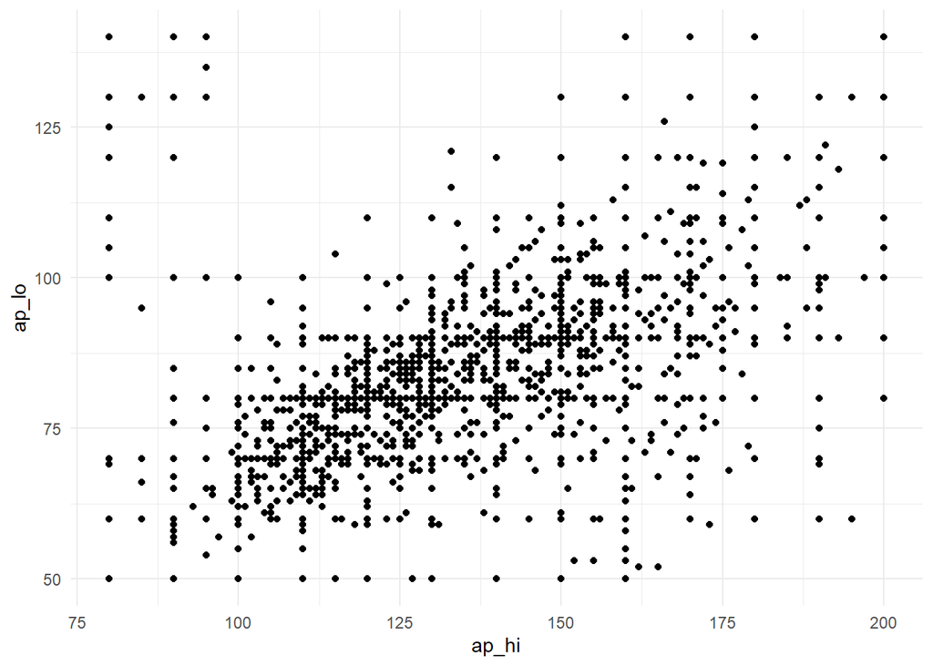

```r
data <- data[data$ap_hi <= 200 & data$ap_lo <= 140, ]
data <- data[data$ap_hi >= 80 & data$ap_lo >= 50, ]

ggplot(data, aes(x = ap_hi, y = ap_lo)) +
  geom_point() +
  labs(x = "ap_hi", y = "ap_lo") +
  theme_minimal()
```

### 3.2.3 Gender detection

We have a binary result for gender: 1 and 2, but we need to characterize it correctly by male and female.

```r
weights_1 = data[data$gender == 1,]$weight
weights_2 = data[data$gender == 2,]$weight

cat("Mean weight value for gender = 1",mean(weights_1),"\n")
```

```
## Mean weight value for gender = 1 72.65673
```

```r
cat("Mean weight value for gender = 2",mean(weights_2),"\n\n")
```

```
## Mean weight value for gender = 2 77.19945
```

```r
heights_1 = data[data$gender == 1,]$height
heights_2 = data[data$gender == 2,]$height

cat("Mean height value for gender = 1",mean(heights_1),"\n")
```

```
## Mean height value for gender = 1 161.4979
```

```r
cat("Mean height value for gender = 2",mean(heights_2))
```

```
## Mean height value for gender = 2 170.0443
```

So knowing that males, even more in a dataset of this size, have in avergare higher height and weight:

```r
data$gender <- ifelse(data$gender == 1, "F", "M")
data$gender <- as.factor(data$gender)
```

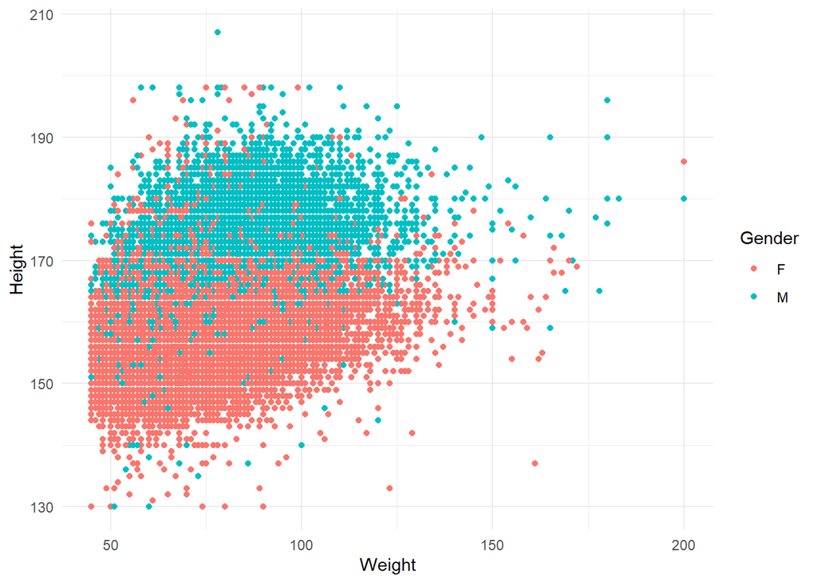

```r
ggplot(data, aes(x = weight, y = height, color = gender)) +
  geom_point() +
  labs(x = "Weight", y = "Height", color = "Gender") +
  theme_minimal()
```

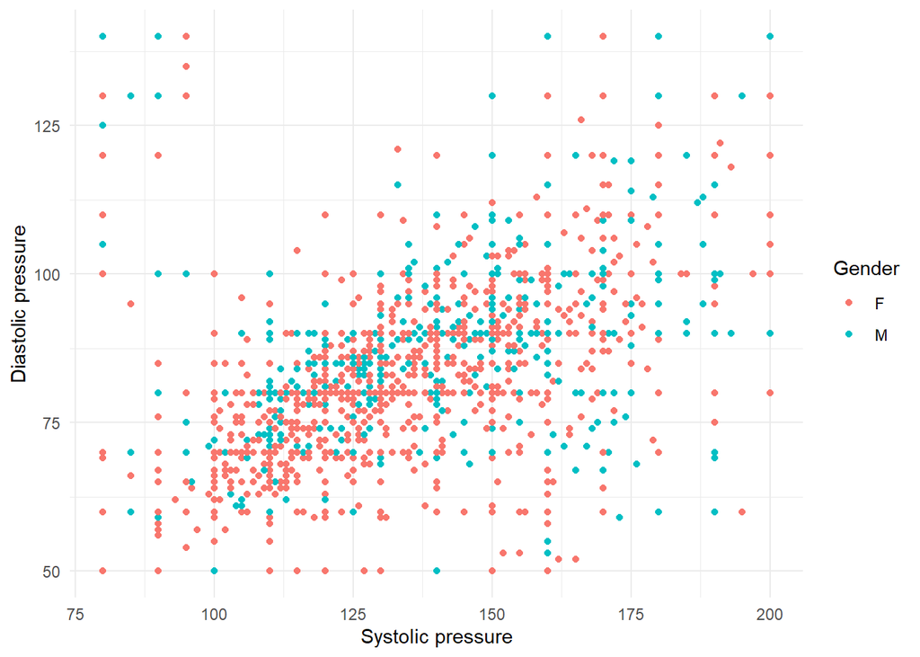

```r
ggplot(data, aes(x = ap_hi, y = ap_lo, color = gender)) +
  geom_point() +
  labs(x = "Systolic pressure", y = "Diastolic pressure", color = "Gender") +
  theme_minimal()
```

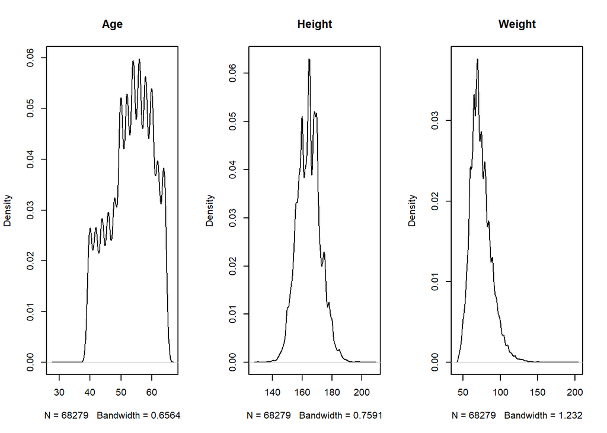

```r
par(mfrow=c(1,3))
plot(density(data$age), main = "Age")
plot(density(data$height), main = "Height")
plot(density(data$weight), main = "Weight")
```

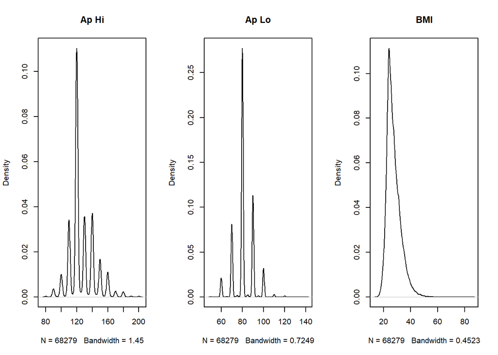

```r
plot(density(data$ap_hi), main = "Ap Hi")
plot(density(data$ap_lo), main = "Ap Lo")
plot(density(data$BMI), main = "BMI")
```

### 3.2.4 Factorization of discrete variables

Now for the finale variables, those that are discrete over certain ranges of values, specified in the variables descriptions, we can study their representations and factor them.

```r
table(data$cholesterol)
```

```
##
##     1     2     3
## 51200  9239  7840
```

```r
table(data$gluc)
```

```
##
##     1     2     3
## 58042  5036  5201
```

```r
table(data$smoke)
```

```
##
##     0     1
## 62254  6025
```

```r
table(data$alco)
```

```
##
##     0     1
## 64618  3661
```

```r
table(data$active)
```

```
##
##     0     1
## 13432 54847
```

```r
table(data$cardio)
```

```
##
##     0     1
## 34439 33840
```

```r
data$cholesterol <- as.factor(data$cholesterol)
data$gluc <- as.factor(data$gluc)
data$smoke <- as.factor(data$smoke)
data$alco <- as.factor(data$alco)
data$cardio <- as.factor(data$cardio)
```

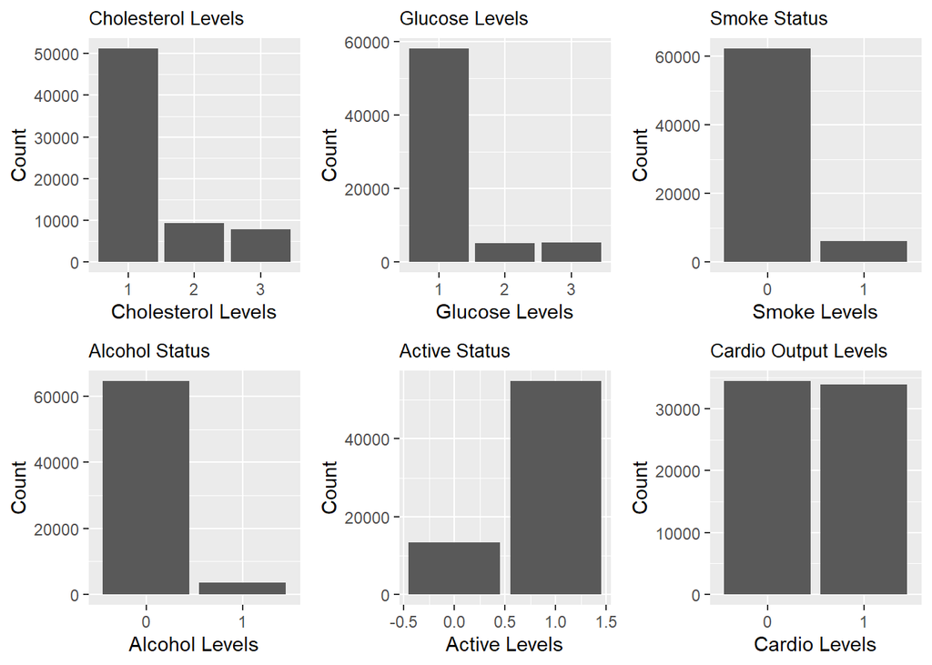

```r
p1 <- ggplot(data, aes(x = cholesterol)) +
  geom_bar() +
  labs(title = "Cholesterol Levels",
       x = "Cholesterol Levels",
       y = "Count") +
  theme(plot.title = element_text(size = 10)) # Adjust size here

p2 <- ggplot(data, aes(x = gluc)) +
  geom_bar() +
  labs(title = "Glucose Levels",
       x = "Glucose Levels",
       y = "Count") +
  theme(plot.title = element_text(size = 10)) # Adjust size here

p3 <- ggplot(data, aes(x = smoke)) +
  geom_bar() +
  labs(title = "Smoke Status",
       x = "Smoke Levels",
       y = "Count") +
  theme(plot.title = element_text(size = 10)) # Adjust size here

p4 <- ggplot(data, aes(x = alco)) +
  geom_bar() +
  labs(title = "Alcohol Status",
       x = "Alcohol Levels",
       y = "Count") +
  theme(plot.title = element_text(size = 10)) # Adjust size here

p5 <- ggplot(data, aes(x = active)) +
  geom_bar() +
  labs(title = "Active Status",
       x = "Active Levels",
       y = "Count") +
  theme(plot.title = element_text(size = 10)) # Adjust size here

p6 <- ggplot(data, aes(x = cardio)) +
  geom_bar() +
  labs(title = "Cardio Output Levels",
       x = "Cardio Levels",
       y = "Count") +
  theme(plot.title = element_text(size = 10)) # Adjust size here

grid.arrange(p1, p2, p3, p4, p5, p6, nrow = 2, ncol = 3)
```